# Data Exploration Report

Shafayet Shariar Hossain

4/30/2022

## Load packages and data

```r
library(tidyverse)
library(ggplot2)
library(svglite)
library(knitr)

clean_data <- read.table(here::here('Data','SEER_breast_cancer_Clean.csv'), header = TRUE, sep = ',')

## Change Variable Types

clean_data <- clean_data |>
  mutate_at(vars(-Year.of.diagnosis,-Survival.months),as.factor)
```

## Data Exploration

The SEER breast cancer data involves patient demographic information i.e. age, sex, race and their diagnostic information regarding breast cancer. The age variable in the dataset is grouped data that is why exact age of the patient is unknown. The dataset also includes variables regarding the surgery treatment of the patients and their corresponding survival months. Therefore, exploratory data analysis can reveal questions such as age distributions of breast cancer patients and many more. Below some exploratory analysis have been done to extract some insight from the dataset.

## Age Distribution of Breast Cancer Patients

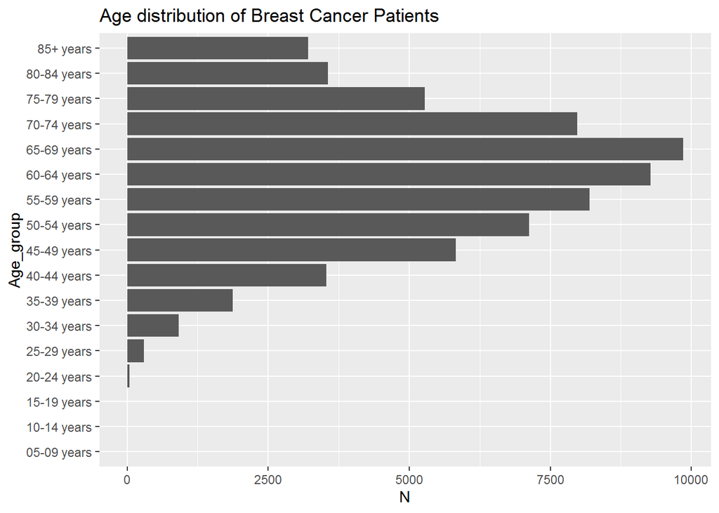

```r
age_distribution <- ggplot(clean_data |>
                          group_by(Age_group)|>
                          summarise( N = n()))+
  aes(x=Age_group, y=N) +
  geom_bar(stat = "identity") +
  coord_flip()+
  labs(title = 'Age distribution of Breast Cancer Patients')

age_distribution
```

The age distribution of the breast cancer patients shows that most of the patients are aged between approximately 50-70 years. The distribution peaks mostly around those groups. However, there are also significant amount of breast cancer patients that are relatively young. The distribution also resembles normal distribution. In the lower age groups, there are very few patients in number. That is why those bars are not visible in the graph.

## Age group by Race

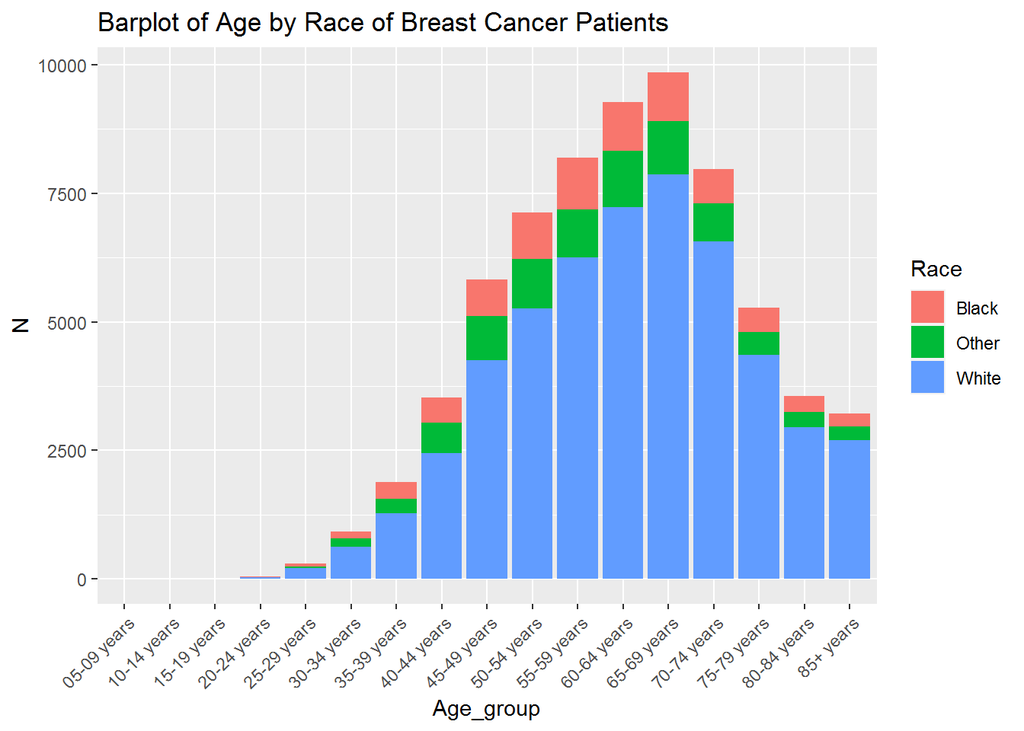

```r
agexrace <- ggplot(clean_data |>
                            group_by(Age_group,Race)|>
                            summarise( N = n()))+
  aes(x=Age_group, y=N, fill = Race) +
  geom_bar(stat = "identity") +
  labs(title = 'Barplot of Age by Race of Breast Cancer Patients')

agexrace <- agexrace + guides(x = guide_axis(angle = 45))

agexrace
```

## Survival Months distribution by Race

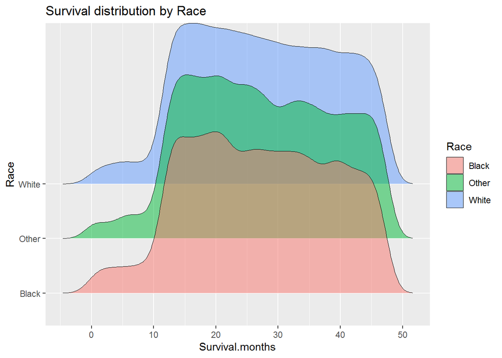

```r
survivalxrace <- ggplot(clean_data)+
  aes(x=Survival.months, y = Race, fill = Race) +
  ggridges::geom_density_ridges(size = .2, alpha = .5, scale = 3) +
  labs(title = 'Survival distribution by Race')

survivalxrace
```

The survival months distribution across different race shows all the race experience similar distribution in terms of their survival months. Therefore, we can gather insight that the survival trajectory of patients haven’t been affected by the race they are part of.

## Survival Months Distribution by Cancer Grade

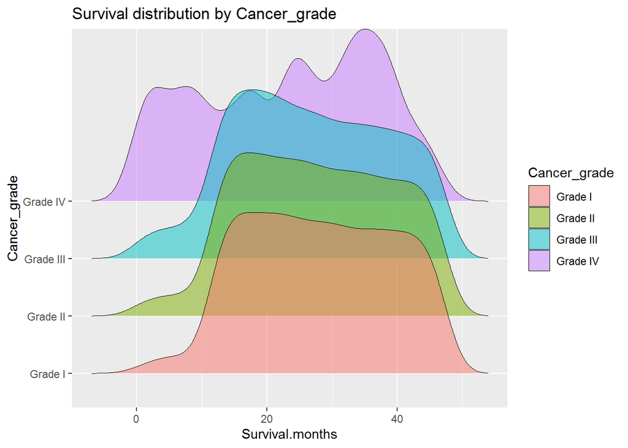

```r
survivalxgrade <- ggplot(clean_data|>
                           mutate(Cancer_grade = fct_relevel(Cancer_grade,
                                                             "Grade I", "Grade II",
                                                             "Grade III", "Grade IV")))+
  aes(x=Survival.months, y = Cancer_grade, fill = Cancer_grade) +
  ggridges::geom_density_ridges(size = .2, alpha = .5, scale = 3) +
  labs(title = 'Survival distribution by Cancer_grade')

survivalxgrade
```

The stage of a cancer describes the size of a tumour and how far it has spread from where it originated. It describes the appearance of the cancerous cells. The staging of cancer is done through cancer grade and the higher the grade the higher the spread of the cancerous cells. The above graph shows the distribution of survival months in different cancer grades. And it can be observed that grade IV has a completely different survival month distribution compared to other cancer grades. Also, grades I II and III have similar distribution.

## Survival Months by Age Group

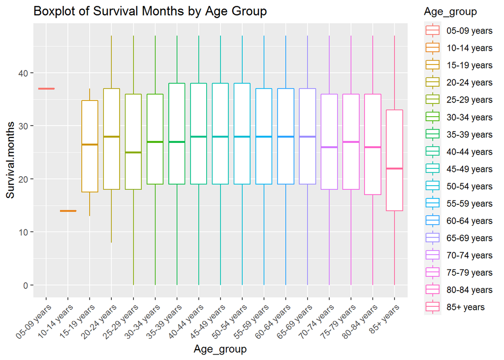

```r
survivalxage <- ggplot(clean_data) +
  aes(x = Age_group,
      y = Survival.months,
      color = Age_group) +
  geom_boxplot()+
  labs(title = "Boxplot of Survival Months by Age Group")


survivalxage <- survivalxage + guides(x = guide_axis(angle = 45))

survivalxage
```

## Survival Months by Primary Site

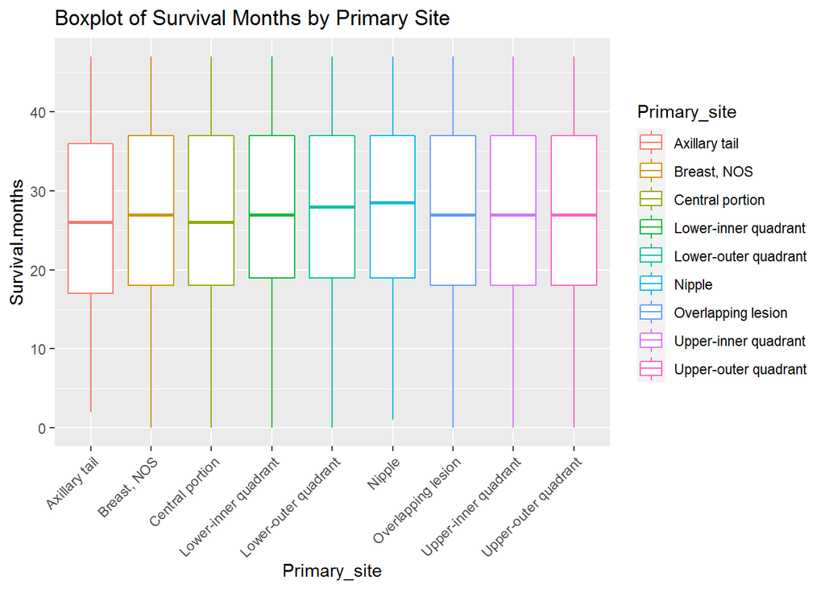

```r
survivalxsite <- ggplot(clean_data) +
  aes(x = Primary_site,
      y = Survival.months,
      color = Primary_site) +
  geom_boxplot()+
  labs(title = "Boxplot of Survival Months by Primary Site")


survivalxsite <- survivalxsite + guides(x = guide_axis(angle = 45))

survivalxsite
```

The above graph shows whether the quantiles of the survival months of the breast cancer patients different across primary site of the cancer. Primary site of the cancer means where the cancerous origininated initially. In the graph the survival months haven’t differ across different primary sites of the cancer.

## Survival Months by surgery

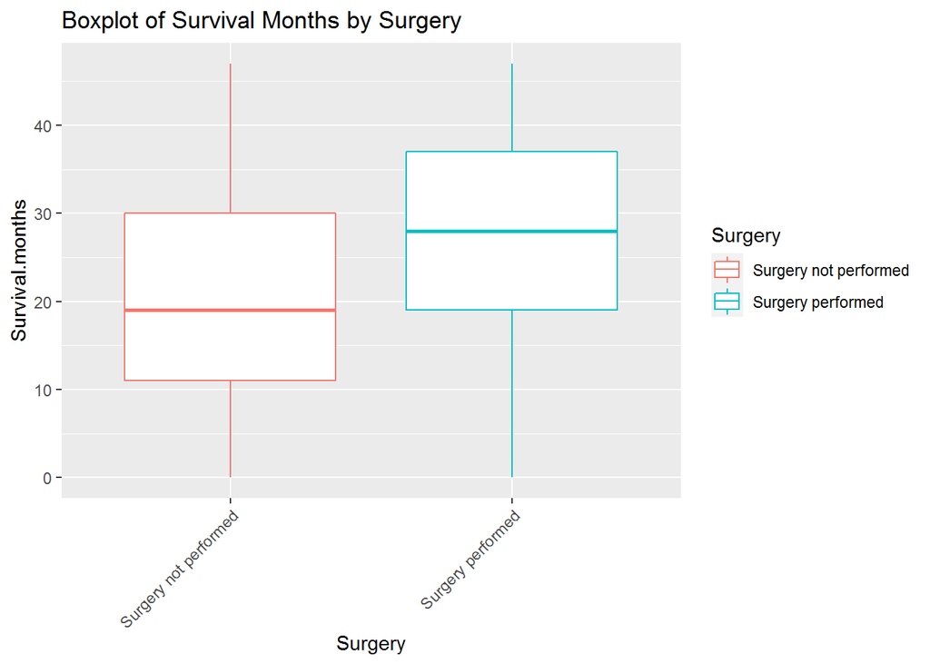

```r
survivalxsurgery <- ggplot(clean_data) +
  aes(x = Surgery,
      y = Survival.months,
      color = Surgery) +
  geom_boxplot()+
  labs(title = "Boxplot of Survival Months by Surgery")


survivalxsurgery <- survivalxsurgery + guides(x = guide_axis(angle = 45))

survivalxsurgery
```

The above graph shows the distribution of survival months for patients who had surgery and who hadn’t. From the boxplot it can be concluded that the median survival time is higher for patients who had surgery compared to those who did not have a surgery. Therefore, there is a hint that surgery has helped prolonging patient’s survival.

## Survival months by Laterality

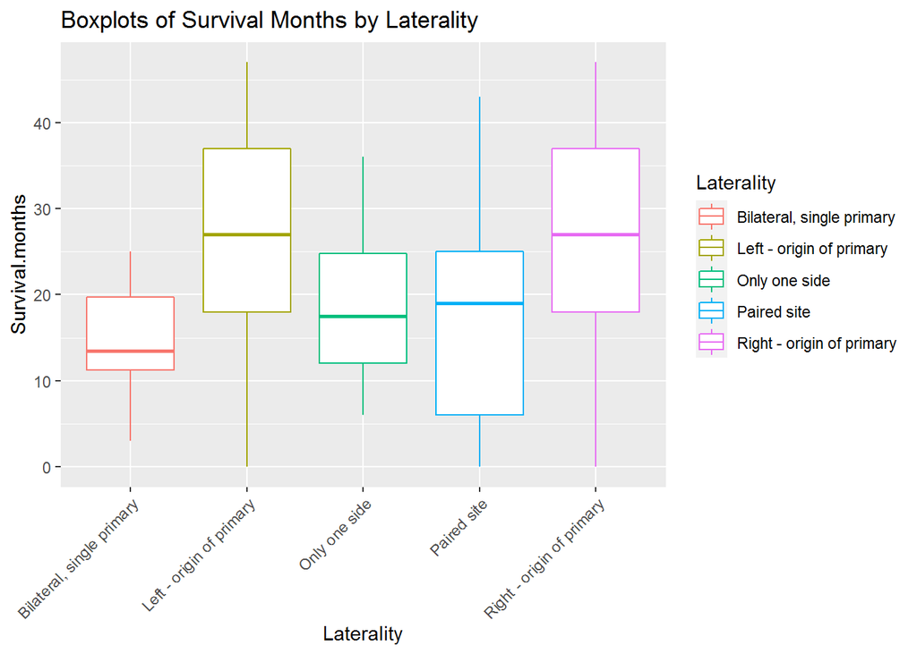

```r
survivalxlaterality <- ggplot(clean_data) +
  aes(x = Laterality,
      y = Survival.months,
      color = Laterality) +
  geom_boxplot()+
  labs(title = "Boxplots of Survival Months by Laterality")


survivalxlaterality <- survivalxlaterality + guides(x = guide_axis(angle = 45))

survivalxlaterality
```

Cancer laterality of breast cancer means which side of the breasts the cancerous cells has spread. The above graph shows the distribution of survival months across the laterality of breast cancer. From the graph it can be observed that patients with cancer only one side of the breast cancer (left/right) has higher median survival month compared to other lateralities. It also makes sense as cancer cells on one side of the pair of breast will have higher survival times compared to both.

## Survival Months by Cause of Death

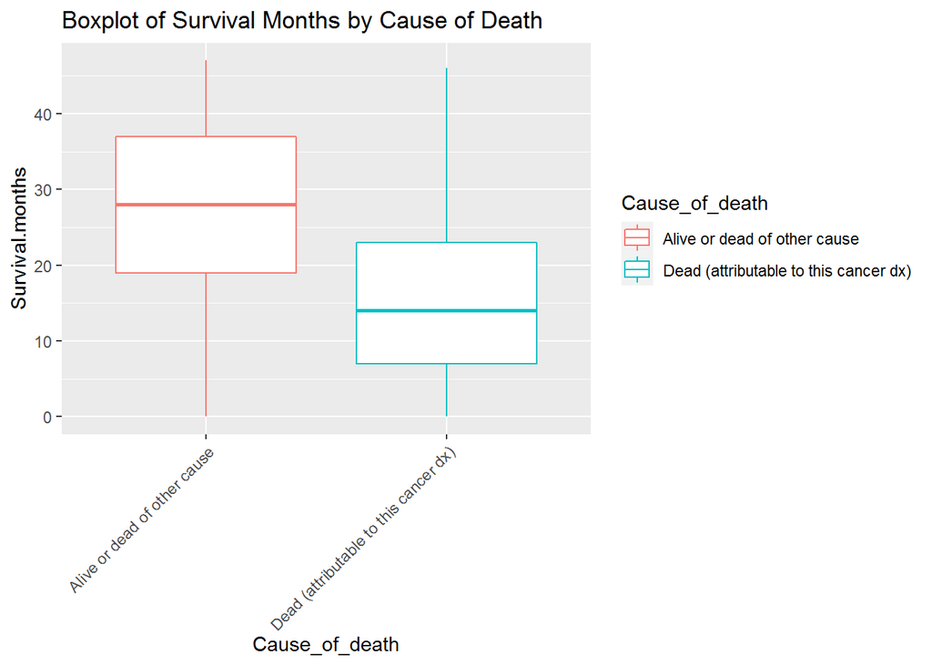

```r
survivalxcod <- ggplot(clean_data) +
  aes(x = Cause_of_death,
      y = Survival.months,
      color = Cause_of_death) +
  geom_boxplot()+
  labs(title = "Boxplot of Survival Months by Cause of Death")


survivalxcod <- survivalxcod + guides(x = guide_axis(angle = 45))

survivalxcod
```

The above graph shows the survival month distribution of patients who died because of breast cancer and who died of other causes. The median survival month of patients who died of breast cancer is lower compared to those who are alive or dead because of other disease.

## Proportions of Surgery on Cancer Histology type.

The cancer histology type is a description of a tumor based on how abnormal the cancer cells and tissue look under a microscope and how quickly the cancer cells are likely to grow and spread. We wanted to see if there is any histologic type which didn’t require surgery rather other treatment procedures e.g. chemotherapy, radiationtherapy etc. The following table shows the proportion of patients who had surgery and who hadn’t based on their corresponding histology type. The proportions tells us in each of the histology types majority of the patients had surgery and no histology type had an opposite case where the majority did not have a surgery.

```r
clean_data |>
  group_by(Histology_Type, Surgery) |>
  summarise(n=n()) |>
  mutate(prop = n/sum(n)) |>
  subset(select = c("Surgery", "Histology_Type", "prop"))|>
  spread(Surgery, prop) |>
  kable()
```

| Histology_Type | Surgery not performed | Surgery performed |
| --- | --- | --- |
| acinar cell neoplasms | NA | 1.0000000 |
| adenomas and adenocarcinomas | 0.0970724 | 0.9029276 |
| adnexal and skin appendage neoplasms | 0.0963303 | 0.9036697 |
| blood vessel tumors | 0.0370370 | 0.9629630 |
| complex epithelial neoplasms | 0.0315186 | 0.9684814 |
| complex mixed and stromal neoplasms | 0.1333333 | 0.8666667 |
| cystic, mucinous and serous neoplasms | 0.0600480 | 0.9399520 |
| ductal and lobular neoplasms | 0.0744092 | 0.9255908 |
| epithelial neoplasms, NOS | 0.3843284 | 0.6156716 |
| fibroepithelial neoplasms | NA | 1.0000000 |
| fibromatous neoplasms | NA | 1.0000000 |
| mucoepidermoid neoplasms | NA | 1.0000000 |
| myomatous neoplasms | NA | 1.0000000 |
| osseous and chondromatous neoplasms | NA | 1.0000000 |
| soft tissue tumors and sarcomas, NOS | 0.0666667 | 0.9333333 |
| squamous cell neoplasms | 0.0975610 | 0.9024390 |
| transitional cell papillomas and carcinomas | NA | 1.0000000 |
| unspecified neoplasms | 0.2500000 | 0.7500000 |